# 1. Process Variant Calls

Will Hannon

28 April, 2023

The goal of this notebook is to determine the quality of the variant calling data. What is the overlap between the different variant callers? How much coverage do we have in each sample? Are there samples that are problematic in some way? Finally, how do we combine variants from `lofreq` and `varscan` into a unified set to go forward with? **The output of this notebook is a filtered and unified set of variants from `lofreq` and `varscan`.**

The data used in this notebook are the variant calls from the programs `varscan` and `lofreq`. Variants were called relative an `SSPE` patient-specific consensus genome that incorporates SNPs present at >=90% frequency in more than 12/15 total brain samples. We consider these SNPs to be ‘fixed’ and ‘ancestral’ to all viral sequences isolated from the brain.

```r
## ==== File paths input data ==== ##

if (exists("snakemake")) {

  # Variant data parsed from from lofreq and varscan VCF files
  variant.data = snakemake@input[[1]]

  # Annotations for the standard Measles ORFs for making figures.
  annotations.filepath = snakemake@params[['annotations']]

  # Depth information for each tissue
  merged.depth = snakemake@input[[2]]

} else {

  # Variant data parsed from from lofreq and varscan VCF files
  variant.data = "../../results/variants/variants.csv"

  # Annotations for the standard Measles ORFs ~ for making pretty figures.
  annotations.filepath = "../../config/annotations.csv"

  # Depth information for each tissue
  merged.depth = "../../results/coverage/merged.depth"
}
```

```r
## ==== File paths output data ==== ##

if (exists("snakemake")) {

  # Variant calls unified from both lofreq and varscan
  output.path = snakemake@params[['outcsv']]

  # Path to save figures
  figure.dir = paste0(snakemake@params[['figures']], "/")

} else {

  # Variant calls unified from both lofreq and varscan
  output.path = "../../results/variants/filtered_variants.csv"

  # Path to save figures
  figure.dir = "../../results/figures/"

}

# Make the figure directory if it doesn't exist
if (!file.exists(figure.dir)) {
  dir.create(figure.dir, recursive = TRUE)
  print("Directory created.")
} else {
  print("Directory already exists.")
}
```

```
## [1] "Directory already exists."
```

## Processing Variant Calls

```r
# Minimum allele frequency to be included in analysis.
min_AF = 0.02
# Minimum read depth to be included in analysis.
min_DP = 200
```

I used two different variant callers to identify mutations in the measles virus genome. In the absence of biological replicates, this is a way to control for issues in the variant calling pipelines that could result in spurious variants. In addition to these different variant calling approaches, I’ve set a cutoff of 200X coverage and a minimum allele frequency of 2% of reads.

To identify a set of mutations to go forward with, I’ll combine the mutations from each variant caller in order to handle SNPs that might be lower frequency in a single sample due to low coverage.

```r
# Import lofreq data and filter
lofreq.variant.df = read_csv(variant.data, show_col_types = FALSE) %>%
  filter(Caller == 'lofreq') %>%
  mutate(SNP = paste0(REF, POS, ALT)) %>%
  mutate(Type = case_when(nchar(REF) > 1 ~ "Del",
                          nchar(ALT) > 1 ~ "Ins",
                          nchar(REF) == 1 ~ "SNP")) %>%
  filter(Type == "SNP") %>%
  filter(DP >= min_DP) %>%
  filter(AF >= min_AF)

# Import varscan data and filter
varscan.variant.df = read_csv(variant.data, show_col_types = FALSE) %>%
  filter(Caller == 'varscan') %>%
  mutate(SNP = paste0(REF, POS, ALT)) %>%
  mutate(Type = case_when(nchar(REF) > 1 ~ "Del",
                          nchar(ALT) > 1 ~ "Ins",
                          nchar(REF) == 1 ~ "SNP")) %>%
  filter(Type == "SNP") %>%
  filter(DP >= min_DP) %>%
  filter(AF >= min_AF)
```

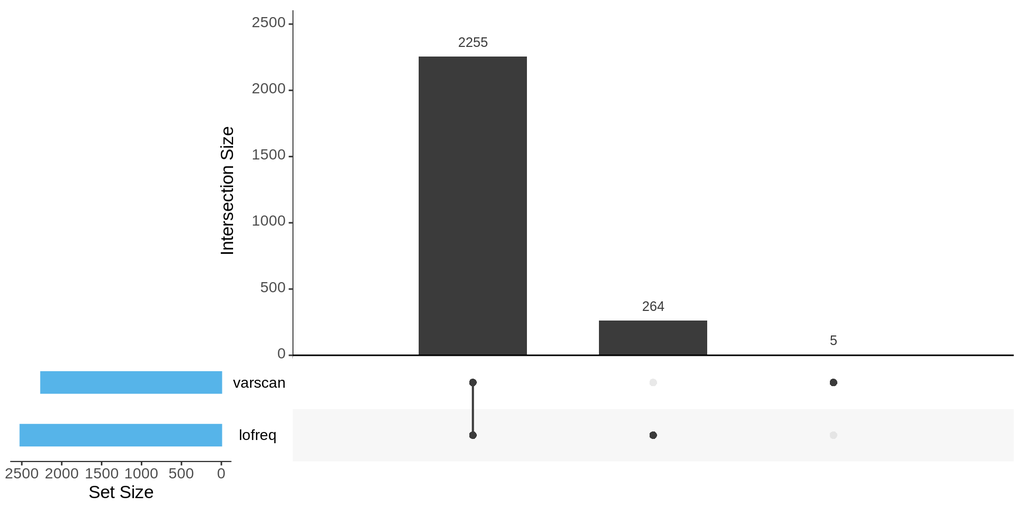

```r
# Total unique variants called in both lofreq and varscan
total.variants = combined.variants.df %>%
  select(SNP, Caller) %>%
  distinct() %>%
  group_by(SNP) %>%
  count() %>%
  filter(n == 2) %>%
  pull(SNP)

# Then, I'll figure out how many of these are missing in a specific tissue in one method
missing.from.one = combined.variants.df %>%
  filter(SNP %in% total.variants) %>%
  select(SNP, Accession, Caller) %>%
  group_by(SNP, Accession) %>%
  count() %>%
  filter(n < 2)

print(paste("There are", length(unique(pull(missing.from.one, SNP))), "instances in which one variant caller picks up on a mutation that's missing from the other."))
```

```
## [1] "There are 95 instances in which one variant caller picks up on a mutation that's missing from the other."
```

```r
# High-quality SNPs that are missing from one method in a given tissue
snps.to.resolve = missing.from.one %>%
  select(SNP, Accession) %>%
  mutate(resolve_ID = paste(SNP, Accession, sep = "-")) %>%
  pull(resolve_ID)

# Most are in lofreq and missing from varscan. I'll add these to the varscan data.
missing.snps.from.varscan = combined.variants.df %>%
  mutate(resolve_ID = paste(SNP, Accession, sep = "-")) %>%
  filter(resolve_ID %in% snps.to.resolve) %>%
  filter(Caller == "lofreq") %>%
  select(!resolve_ID)

# Added to the varscan data.
selected.variants.df = combined.variants.df %>%
  filter(Caller == "varscan") %>%
  rbind(., missing.snps.from.varscan) %>%
  select(!c("Caller", "Virus", "Host", "R1", "R2", "Type", "Sample", "Approach"))
```

```
## [1] "In total, there are 535 unqiue SNPs in the brain."
```

```
## [1] "Writing out the variants to results/variants/filtered_variants.csv"
```

## Visualize Subclonal Variants

What are the distribution of these SNPs in the Measles genome in each tissue? This will help to identify the regions of the genome in which we can most confidently assign mutations to specific genetic backgrounds with read support. This will be relevant after we cluster mutations by frequencies.

Note that some regions appear to have gaps in the appearance of SNPs. These are due to regions of low coverage. I’ll highlight this by identifying regions where depth is less than 200 reads - the minimum required for calling a variant.

```r
# Import and process information about coverage/read depth
tissue.df = selected.variants.df %>% select(Accession, Tissue) %>% unique()
merged.depth.df = fread(merged.depth) %>%
  select(!V1) %>%
  left_join(., tissue.df, by = "Accession") %>%
  select(-Accession)

# Get only the contiguous regions of low depth per Accession
low.coverage.regions = merged.depth.df %>%
  filter(DP < 200) %>%
  select(-DP) %>%
  group_by(Tissue) %>%
  mutate(Block = cumsum(c(1, diff(POS) > 1))) %>%
  group_by(Tissue, Block) %>%
  mutate(x1 = min(POS), x2 = max(POS)) %>%
  ungroup() %>%
  select(-Block, -POS) %>%
  distinct() %>%
  arrange(x1, Tissue) %>%
  filter((x2 - x1) > 0) %>%
  mutate(POS = x1)

# Convert tissue into a factor
low.coverage.regions$Tissue = factor(low.coverage.regions$Tissue, levels=rev(tissue_order), ordered=TRUE)
low.coverage.regions = low.coverage.regions %>%
  mutate(y = as.integer(Tissue),
         y1 = y - 0.2,
         y2 = y + 0.2)
```

Any block colored in red indicates a region of low coverage where read depth is below 200 reads.

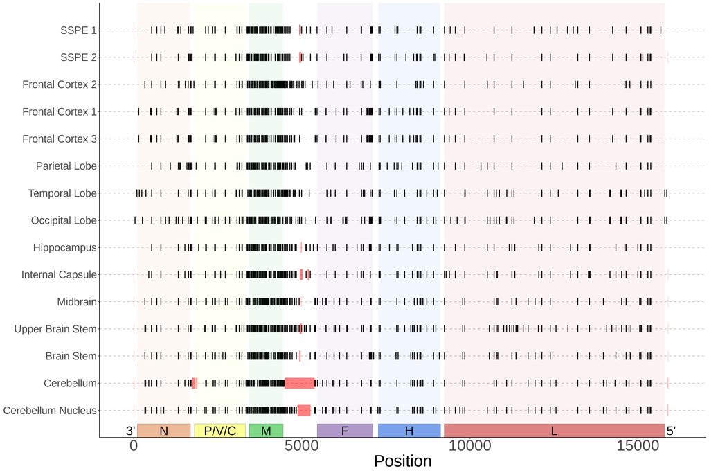